# Complexity Hierarchies And Little-o Notation

```python
import numpy as np
import matplotlib.pyplot as plt
```

## Hypothesizing Hierarchies via Plotting

Let's first look at a plot of different functions that are commonly used to describe the complexity of algorithms in big O notation. We're interested in long time behavior, so it appears that the hierarchy is

$ 1 < \log(N) < N < N^2 < N^3 < 2^N < N! $

But we need some mathematical tools to prove this

```python
def fac(N):
    # fac(N) = N*(N-1)*(N-2)*...*1
    res = 1
    for i in range(1, N+1):
        res *= i
    return res
```

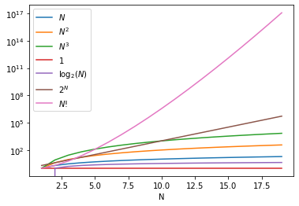

```python
N = np.arange(1, 20)
plt.plot(N, N) # N
plt.plot(N, N**2) #N^2
plt.plot(N, N**3) #N^3
plt.plot(N, np.ones(len(N))) # Constant
plt.plot(N, np.log2(N))
plt.plot(N, 2**N) # Exponential, 2^N
plt.plot(N, [fac(i) for i in N]) # N!
plt.legend(["$N$", "$N^2$", "$N^3$", "$1$", "$\log_2(N)$", "$2^N$", "$N!$"])
plt.yscale("log")
plt.xlabel("N")
```

## Little o Notation / Dominating Functions

Def. Big-O Notation: A function $f(N)$ is $O(g(N))$ if it is possible to find a constant $c > 0$ and a constant $n_c$ so that

$f(N) \leq cg(N), N > n_c$

Big-O Notation provides an upper bound

Def. Little-o Notation: A function $f(N)$ is $o(g(N))$ if for all constants $c > 0$ it is possible to find a constant $n_c$ so that

$f(N) \leq cg(N), N > n_c$

Little-o notation says that $f(N)$ is dominated by $g(N)$, or in other words, $f(N)$ grows *strictly* more slowly than $g(N)$

Ex) My worst enemy can come in and say $c = 10^{-100}$

## $\frac{f(N)}{g(N)} \leq c, N > n_c$

Ex) $f(N) = N, g(N) = N^2$ I want to show that $f(N) = N$ is $o(g(N) = N^2)$

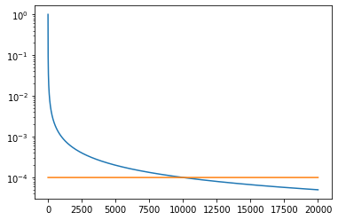

```python
N = np.arange(1, 20001)
f = N
g = N**2
c = 0.0001
plt.plot(N, f/g)
plt.plot(N, c*np.ones(len(N)))
plt.yscale("log")
```

It seems like this is true when we plot, but how do we prove this? We need the following lemma

### Lemma: If the limit

## $\lim_{N -> \infty} \frac{f(N)}{g(N)} = 0$, then $f(N)$ is $o(g(N))$

Let's now go back to our example and show the limit of the ratios is zero

Ex) $f(N) = N, g(N) = N^2$

$\lim_{N -> \infty} \frac{N}{N^2}$

$\lim_{N -> \infty} \frac{N}{N^2} \frac{(1/N)}{1/N}$

$\lim_{N -> \infty} \frac{1}{N}$ = 0

Implies that $N$ is $o(N^2)$

We can generalize this to any two powers of $N$

Ex) If $f(N) = N^a$ and $g(N)$ is $N^b$, where $b > a$, then $f(N)$ is $o(g(N))$

Any time I have a monomial $f(N)$ which is to a smaller power than another monomial $g(N)$, then $f(N)$ is $o(g(N))$

$N$ is $o(N^2)$

$N^2$ is $o(N^3)$

$N$ is $o(N^3)$

$1$ is $o(N^a), a \geq 1$

$1$ is $o(\sqrt{N})$

$\sqrt{N}$ is $o(N)$

Let's look at an example that's slightly different in nature

Ex) $f(N) = N^2$, $g(N) = 2^N$, want to prove that $f(N)$ is $o(g(N))$

Need to show that

### $\lim_{N -> \infty} \frac{N^2}{2^N} = 0$

We need some new machinery to show this rigorously. I'm going to put my math 111 hat back on now

## Thm. L'Hopsital's Rule

If $\lim_{N -> \infty} f(N) = \infty$

and

$\lim_{N -> \infty} g(N) = \infty$

and the limit exists

### $\lim_{N -> \infty} \frac{f(N)}{g(N)} = \lim_{N -> \infty} \frac{f'(N)}{g'(N)} $

Going back to our example, we can apply L'Hospital's rule twice to complete the proof that $f(N)$ is $o(g(N))$

Ex) $f(N) = N^2$, $g(N) = 2^N$

$f'(N) = 2N$

$g'(N) = \ln(2) 2^N$

### $\lim_{N -> \infty} \frac{2N}{\ln(2) 2^N}$

$f''(N) = 2$

$g''(N) = \ln(2)^2 2^N$

### $\lim_{N -> \infty} \frac{2}{\ln(2)^2 2^N} = \frac{2}{\infty} = 0$

This proves that $N^2$ is $o(2^N)$, but it is actually true (using similar proof techniques) that $N^a$ is $o(b^N)$. In other words, every power of $N$ is dominated by every exponential. So, for example, even $N^{10,000}$ is $o(1.1^N)$. So we think of exponentials as having particularly bad time complexity